# Linear regression

## Linear regression

```r
finaldata <- read.csv(here("data", "analytical", "finaldata.csv"), header = TRUE)
head(finaldata)
```

```
  country_name ISO        region year   gdp1000 OECD OECD2023  popdens    urban
1  Afghanistan AFG Southern Asia 2000        NA    0        0 14.13654 16.25324
2  Afghanistan AFG Southern Asia 2001        NA    0        0 14.23156 16.25661
3  Afghanistan AFG Southern Asia 2002 0.1835328    0        0 14.32270 16.42654
4  Afghanistan AFG Southern Asia 2003 0.2004626    0        0 14.40691 16.60701
5  Afghanistan AFG Southern Asia 2004 0.2216576    0        0 15.21947 16.71367
6  Afghanistan AFG Southern Asia 2005 0.2550551    0        0 15.33619 16.85096
    agedep male_edu     temp rainfall1000 matmor infmor neomor un5mor
1 108.3466 2.762086 12.69959    0.2763704   1450   90.5   60.9  129.2
2 108.9899 2.856936 12.85570    0.2793079   1390   87.9   59.7  125.2
3 109.3472 2.954241 12.71081    0.3805710   1300   85.3   58.5  121.1
4 109.4475 3.054121 12.16592    0.4288939   1240   82.7   57.2  116.9
5 109.2868 3.156706 13.04643    0.3754336   1180   80.0   55.9  112.6
6 107.9646 3.262133 12.23141    0.4415680   1140   77.3   54.6  108.4
  earthquake drought totdeath armconf1
1          1       0     5065        1
2          0       1     5394        1
3          0       1     5553        1
4          0       1     1157        1
5          0       1      944        1
6          0       1      817        1
```

```r
names(finaldata)
```

```
 [1] "country_name" "ISO"          "region"       "year"         "gdp1000"
 [6] "OECD"         "OECD2023"     "popdens"      "urban"        "agedep"
[11] "male_edu"     "temp"         "rainfall1000" "matmor"       "infmor"
[16] "neomor"       "un5mor"       "earthquake"   "drought"      "totdeath"
[21] "armconf1"
```

The model presented on page 6 in the paper is

$$\text{Outcome}_{ij} = \beta_{0} + \beta_{1}\text{Conflict}_{i(t-1)} + \beta_2\text{Covariates}_{it} + i + t + u_{it}$$

where $i$ is the country, $t$ is the year, and $u_{it}$ is the error term. We will first use maternal mortality `MatMor` as the $\text{Outcome}_{ij}$ and binary armed conflict specification `armconf1` as the main predictor $\text{Conflict}_{i(t-1)}$. The set of $\text{Covariates}_{it}$ are those included in Table 2. By the way, I think the authors made a careless mistake in writing out the model here. Since there are multiple covariates, $\beta_2$ should be presented as a vector…

```r
finaldata$pctpopdens <- finaldata$popdens / 100
matmormod <- lm(matmor ~ -1 + armconf1 + gdp1000 + OECD + pctpopdens + urban +
                  agedep + male_edu + temp + rainfall1000 + earthquake + drought +
                  ISO, data = finaldata)
matmorplm <- plm(matmor ~ armconf1 + gdp1000 + OECD + pctpopdens + urban +
                  agedep + male_edu + temp + rainfall1000 + earthquake + drought,
                 index = c("ISO"),
                 model = "within",
                 data = finaldata)
htmlreg(list(matmormod, matmorplm))
```

Statistical models

|  | Model 1 | Model 2 |
| --- | --- | --- |
| armconf1 | 39.54*** | 39.54*** |
|  | (4.40) | (4.40) |
| gdp1000 | 2.00*** | 2.00*** |
|  | (0.22) | (0.22) |
| OECD | 17.55 | 17.55 |
|  | (15.37) | (15.37) |
| pctpopdens | -57.12 | -57.12 |
|  | (37.66) | (37.66) |
| urban | -7.63*** | -7.63*** |
|  | (0.97) | (0.97) |
| agedep | 0.11 | 0.11 |
|  | (0.31) | (0.31) |
| male_edu | -63.45*** | -63.45*** |
|  | (3.29) | (3.29) |
| temp | 10.57*** | 10.57*** |
|  | (3.02) | (3.02) |
| rainfall1000 | -7.91 | -7.91 |
|  | (5.99) | (5.99) |
| earthquake | -0.21 | -0.21 |
|  | (4.12) | (4.12) |
| drought | 5.45 | 5.45 |
|  | (4.63) | (4.63) |
| ISOAFG | 1163.91*** |  |
|  | (53.27) |  |
| ISOAGO | 797.25*** |  |
|  | (75.68) |  |
| ISOALB | 745.17*** |  |
|  | (53.88) |  |
| ISOARE | 287.80*** |  |
|  | (82.80) |  |

[output cut: 357 more lines]

***p < 0.001; **p < 0.01; *p < 0.05

```r
matmormod <- lm(matmor ~ -1 + armconf1 + gdp1000 + OECD + pctpopdens + urban +
                  agedep + male_edu + temp + rainfall1000 + earthquake + drought +
                  ISO + as.factor(year), data = finaldata)
matmorplm <- plm(matmor ~ armconf1 + gdp1000 + OECD + pctpopdens + urban +
                  agedep + male_edu + temp + rainfall1000 + earthquake + drought,
                 index = c("ISO", "year"),
                 effect = "twoways",
                 model = "within",
                 data = finaldata)
htmlreg(list(matmormod, matmorplm))
```

Statistical models

|  | Model 1 | Model 2 |
| --- | --- | --- |
| armconf1 | 37.00*** | 37.00*** |
|  | (4.38) | (4.38) |
| gdp1000 | 2.98*** | 2.98*** |
|  | (0.25) | (0.25) |
| OECD | 26.12 | 26.12 |
|  | (15.36) | (15.36) |
| pctpopdens | -54.03 | -54.03 |
|  | (37.32) | (37.32) |
| urban | -6.04*** | -6.04*** |
|  | (0.99) | (0.99) |
| agedep | -0.47 | -0.47 |
|  | (0.32) | (0.32) |
| male_edu | -42.92*** | -42.92*** |
|  | (5.80) | (5.80) |
| temp | 9.94** | 9.94** |
|  | (3.13) | (3.13) |
| rainfall1000 | -2.16 | -2.16 |
|  | (6.04) | (6.04) |
| earthquake | -0.78 | -0.78 |
|  | (4.10) | (4.10) |
| drought | 3.90 | 3.90 |
|  | (4.60) | (4.60) |
| ISOAFG | 1165.16*** |  |
|  | (60.06) |  |
| ISOAGO | 724.17*** |  |
|  | (88.07) |  |
| ISOALB | 562.11*** |  |
|  | (77.76) |  |
| ISOARE | 108.50 |  |
|  | (102.68) |  |

[output cut: 392 more lines]

What is the relationship between `matmor` and `gdp1000`?

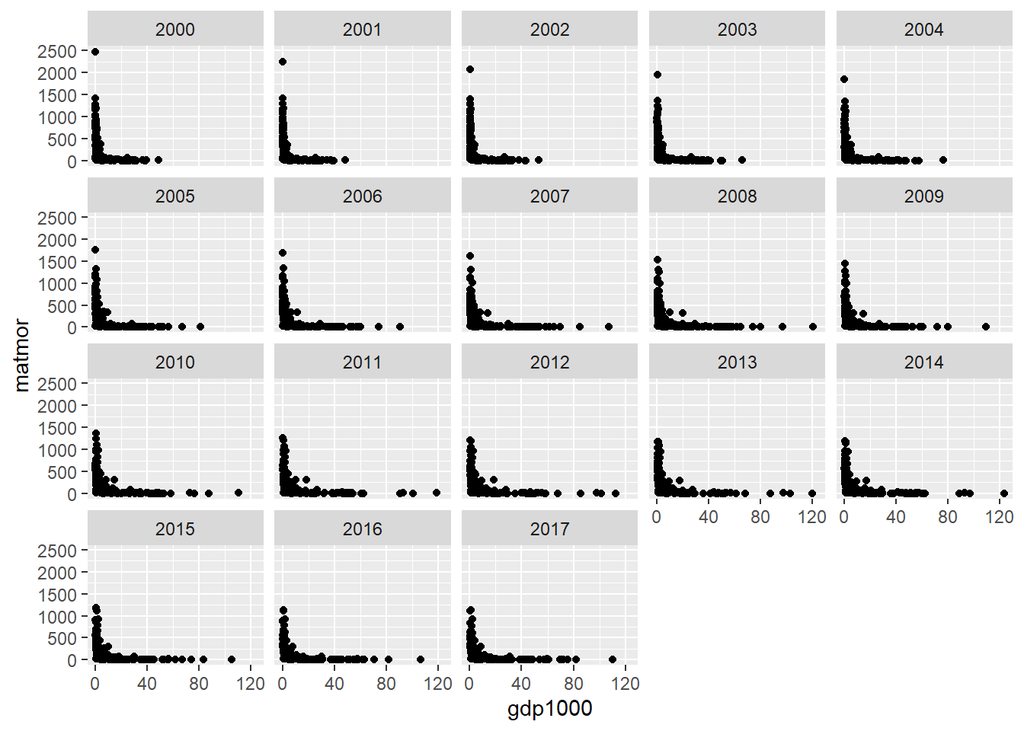

```r
finaldata |>
  dplyr::filter(year < 2018) |>
ggplot(aes(y = matmor, x= gdp1000)) +
  geom_point() +
  facet_wrap(~ year)
```

For example, if we fit a linear regression line for year 2017.

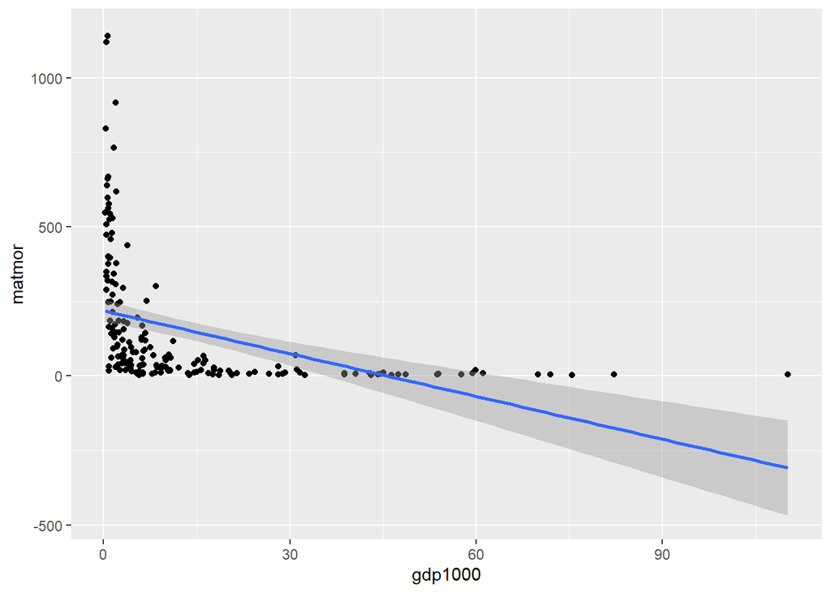

```r
finaldata |>
  dplyr::filter(year == 2017) |>
  ggplot(aes(y = matmor, x= gdp1000)) +
  geom_point() +
  geom_smooth(method='lm')
```

Take the log of GDP

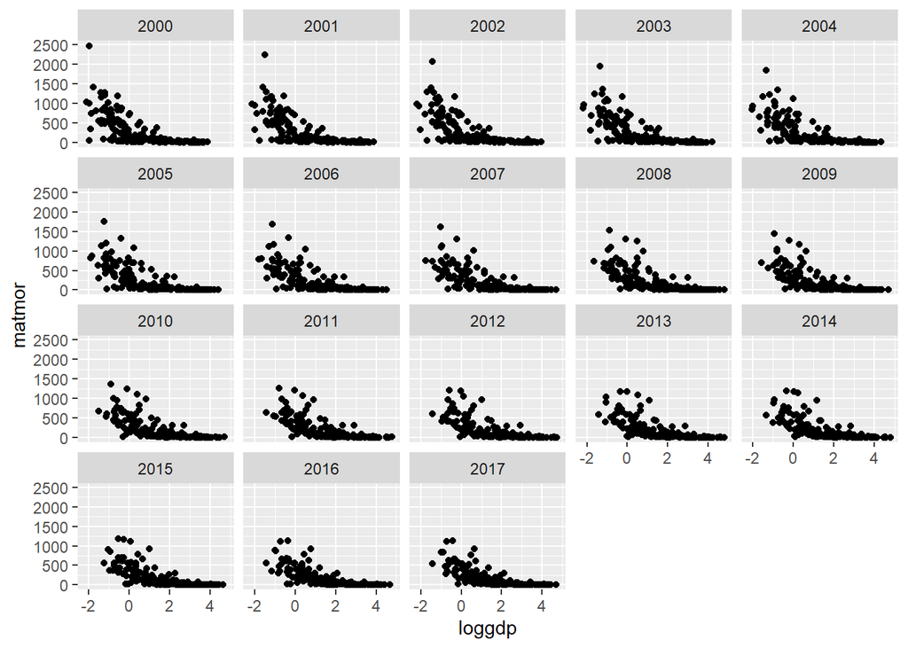

```r
finaldata$loggdp <- log(finaldata$gdp1000)
finaldata |>
  dplyr::filter(year < 2018) |>
ggplot(aes(y = matmor, x= loggdp)) +
  geom_point() +
  facet_wrap(~ year)
```

```r
finaldata$loggdp <- log(finaldata$gdp1000)
matmormod <- lm(matmor ~ -1 + armconf1 + loggdp + OECD + pctpopdens + urban +
                  agedep + male_edu + temp + rainfall1000 + earthquake + drought +
                  ISO + as.factor(year), data = finaldata)
summary(matmormod)
```

```
Call:
lm(formula = matmor ~ -1 + armconf1 + loggdp + OECD + pctpopdens +
    urban + agedep + male_edu + temp + rainfall1000 + earthquake +
    drought + ISO + as.factor(year), data = finaldata)

Residuals:
    Min      1Q  Median      3Q     Max
-400.10  -23.25    1.63   20.17  816.17

Coefficients:
                     Estimate Std. Error t value Pr(>|t|)
armconf1              34.4713     4.4934   7.671 2.28e-14 ***
loggdp               -27.4881     4.7385  -5.801 7.27e-09 ***
OECD                  28.0632    15.6436   1.794 0.072928 .
pctpopdens           -41.6126    37.9800  -1.096 0.273322
urban                 -8.2975     0.9886  -8.394  < 2e-16 ***
agedep                -0.6006     0.3361  -1.787 0.074042 .
male_edu             -60.6274     5.9516 -10.187  < 2e-16 ***
temp                  10.5160     3.1828   3.304 0.000964 ***
rainfall1000          -4.5800     6.1484  -0.745 0.456384
earthquake            -1.2560     4.1783  -0.301 0.763733
drought                4.5035     4.6827   0.962 0.336262
ISOAFG              1202.2940    61.4009  19.581  < 2e-16 ***
ISOAGO               883.4692    90.6725   9.744  < 2e-16 ***
ISOALB               793.0072    80.0784   9.903  < 2e-16 ***
ISOARE               447.0172   107.0810   4.175 3.07e-05 ***
ISOARG              1012.5020    96.6734  10.473  < 2e-16 ***
ISOARM              1031.7170    81.6105  12.642  < 2e-16 ***
ISOATG               729.3003   109.0790   6.686 2.72e-11 ***
ISOAUS              1171.4985   110.1008  10.640  < 2e-16 ***
ISOAUT               994.4406    88.4362  11.245  < 2e-16 ***
ISOAZE               837.4665    84.0961   9.958  < 2e-16 ***
ISOBDI               801.8540    76.6586  10.460  < 2e-16 ***
ISOBEL              1171.1041    99.4891  11.771  < 2e-16 ***
ISOBEN               703.0510    99.9729   7.032 2.50e-12 ***
ISOBFA               392.2547    97.8107   4.010 6.21e-05 ***
ISOBGD               630.8993    96.1779   6.560 6.32e-11 ***
ISOBGR               789.5351    82.9469   9.519  < 2e-16 ***
ISOBHR               750.3833   114.0764   6.578 5.60e-11 ***
ISOBHS               870.3847   109.4419   7.953 2.55e-15 ***
```

[output cut: 172 more lines]

```
as.factor(year)2010   11.3597     9.4676   1.200 0.230290
as.factor(year)2011   17.7702     9.9847   1.780 0.075220 .
as.factor(year)2012   20.5841    10.3952   1.980 0.047776 *
as.factor(year)2013   24.7494    10.8615   2.279 0.022759 *
as.factor(year)2014   26.8068    11.3451   2.363 0.018198 *
as.factor(year)2015   25.2776    11.6038   2.178 0.029455 *
as.factor(year)2016   26.1065    12.0547   2.166 0.030415 *
as.factor(year)2017   31.0645    12.5884   2.468 0.013653 *
---
Signif. codes:  0 '***' 0.001 '**' 0.01 '*' 0.05 '.' 0.1 ' ' 1

Residual standard error: 59.54 on 3014 degrees of freedom
  (497 observations deleted due to missingness)
Multiple R-squared:  0.9732,    Adjusted R-squared:  0.9713
F-statistic: 523.8 on 209 and 3014 DF,  p-value: < 2.2e-16
```

```r
matmorplm <- plm(matmor ~ armconf1 + loggdp + OECD + pctpopdens + urban +
                  agedep + male_edu + temp + rainfall1000 + earthquake + drought,
                 index = c("ISO", "year"),
                 effect = "twoways",
                 model = "within",
                 data = finaldata)
summary(matmorplm)
```

```
Twoways effects Within Model

Call:
plm(formula = matmor ~ armconf1 + loggdp + OECD + pctpopdens +
    urban + agedep + male_edu + temp + rainfall1000 + earthquake +
    drought, data = finaldata, effect = "twoways", model = "within",
    index = c("ISO", "year"))

Unbalanced Panel: n = 181, T = 5-18, N = 3223

Residuals:
     Min.   1st Qu.    Median   3rd Qu.      Max.
-400.0974  -23.2514    1.6297   20.1748  816.1668

Coefficients:
              Estimate Std. Error  t-value  Pr(>|t|)
armconf1      34.47131    4.49343   7.6715 2.279e-14 ***
loggdp       -27.48809    4.73846  -5.8011 7.274e-09 ***
OECD          28.06321   15.64360   1.7939 0.0729277 .
pctpopdens   -41.61256   37.98001  -1.0956 0.2733222
urban         -8.29747    0.98855  -8.3936 < 2.2e-16 ***
agedep        -0.60058    0.33609  -1.7870 0.0740421 .
male_edu     -60.62742    5.95156 -10.1868 < 2.2e-16 ***
temp          10.51600    3.18278   3.3040 0.0009642 ***
rainfall1000  -4.58003    6.14844  -0.7449 0.4563844
earthquake    -1.25603    4.17829  -0.3006 0.7637331
drought        4.50346    4.68266   0.9617 0.3362620
---
Signif. codes:  0 '***' 0.001 '**' 0.01 '*' 0.05 '.' 0.1 ' ' 1

Total Sum of Squares:    11836000
Residual Sum of Squares: 10685000
R-Squared:      0.097207
Adj. R-Squared: 0.034904
F-statistic: 29.5026 on 11 and 3014 DF, p-value: < 2.22e-16
```

```r
screenreg(list(matmormod, matmorplm))
```

```
=============================================
                     Model 1      Model 2
---------------------------------------------
armconf1               34.47 ***    34.47 ***
                       (4.49)       (4.49)
loggdp                -27.49 ***   -27.49 ***
                       (4.74)       (4.74)
OECD                   28.06        28.06
                      (15.64)      (15.64)
pctpopdens            -41.61       -41.61
                      (37.98)      (37.98)
urban                  -8.30 ***    -8.30 ***
                       (0.99)       (0.99)
agedep                 -0.60        -0.60
                       (0.34)       (0.34)
male_edu              -60.63 ***   -60.63 ***
                       (5.95)       (5.95)
temp                   10.52 ***    10.52 ***
                       (3.18)       (3.18)
rainfall1000           -4.58        -4.58
                       (6.15)       (6.15)
earthquake             -1.26        -1.26
                       (4.18)       (4.18)
drought                 4.50         4.50
                       (4.68)       (4.68)
ISOAFG               1202.29 ***
                      (61.40)
ISOAGO                883.47 ***
                      (90.67)
ISOALB                793.01 ***
                      (80.08)
ISOARE                447.02 ***
                     (107.08)
ISOARG               1012.50 ***
                      (96.67)
ISOARM               1031.72 ***
                      (81.61)
ISOATG                729.30 ***
                     (109.08)
ISOAUS               1171.50 ***
```

[output cut: 372 more lines]

```
                      (10.86)
as.factor(year)2014    26.81 *
                      (11.35)
as.factor(year)2015    25.28 *
                      (11.60)
as.factor(year)2016    26.11 *
                      (12.05)
as.factor(year)2017    31.06 *
                      (12.59)
---------------------------------------------
R^2                     0.97         0.10
Adj. R^2                0.97         0.03
Num. obs.            3223         3223
=============================================
*** p < 0.001; ** p < 0.01; * p < 0.05
```

Now we want to fit the model to the other outcomes: `Un5Mor`, `InfMor`, and `NeoMor`. Since we are using the same predictors, it will be efficient to create an object that lists all the predictors and use the object in `lm()` with the `update.formula()` function to run each regression model with different outcomes.

```r
preds <- as.formula(" ~ armconf1 + gdp1000 + OECD + pctpopdens + urban +
                  agedep + male_edu + temp + rainfall1000 + earthquake + drought +
                  ISO + as.factor(year)")

matmormod <- lm(update.formula(preds, matmor ~ .), data = finaldata)
un5mormod <- lm(update.formula(preds, un5mor ~ .), data = finaldata)
infmormod <- lm(update.formula(preds, infmor ~ .), data = finaldata)
neomormod <- lm(update.formula(preds, neomor ~ .), data = finaldata)
```

```r
preds <- as.formula(" ~ armconf1 + loggdp + OECD + pctpopdens + urban +
                  agedep + male_edu + temp + rainfall1000 + earthquake + drought")

matmormod <- plm(update.formula(preds, matmor ~ .), index = c("ISO", "year"), effect = "twoways",
                 model = "within", data = finaldata)
un5mormod <- plm(update.formula(preds, un5mor ~ .), index = c("ISO", "year"), effect = "twoways",
                 model = "within", data = finaldata)
infmormod <- plm(update.formula(preds, infmor ~ .), index = c("ISO", "year"), effect = "twoways",
                 model = "within", data = finaldata)
neomormod <- plm(update.formula(preds, neomor ~ .), index = c("ISO", "year"), effect = "twoways",
                 model = "within", data = finaldata)
screenreg(list(matmormod, un5mormod, infmormod, neomormod), ci.force = TRUE,)
```

```
===================================================================================
              Model 1            Model 2           Model 3           Model 4
-----------------------------------------------------------------------------------
armconf1         34.47 *            2.96 *            1.65 *            0.13
              [  25.66;  43.28]  [  1.56;   4.36]  [  0.93;   2.36]  [-0.15;  0.40]
loggdp          -27.49 *           -8.70 *           -6.13 *           -3.18 *
              [ -36.78; -18.20]  [-10.14;  -7.26]  [ -6.87;  -5.40]  [-3.46; -2.89]
OECD             28.06              6.62 *            3.22 *            1.22 *
              [  -2.60;  58.72]  [  2.15;  11.08]  [  0.94;   5.49]  [ 0.33;  2.11]
pctpopdens      -41.61            -34.45 *          -18.25 *           -5.37 *
              [-116.05;  32.83]  [-45.79; -23.11]  [-24.03; -12.47]  [-7.62; -3.12]
urban            -8.30 *           -1.74 *           -1.01 *           -0.39 *
              [ -10.23;  -6.36]  [ -2.03;  -1.44]  [ -1.16;  -0.86]  [-0.44; -0.33]
agedep           -0.60             -0.06              0.04              0.04 *
              [  -1.26;   0.06]  [ -0.15;   0.04]  [ -0.00;   0.09]  [ 0.03;  0.06]
male_edu        -60.63 *           -9.01 *           -4.82 *           -1.32 *
              [ -72.29; -48.96]  [-10.67;  -7.34]  [ -5.67;  -3.97]  [-1.66; -0.99]
temp             10.52 *            2.42 *            1.15 *            0.30 *
              [   4.28;  16.75]  [  1.41;   3.43]  [  0.64;   1.67]  [ 0.10;  0.50]
rainfall1000     -4.58             -0.04              0.02             -0.13
              [ -16.63;   7.47]  [ -1.95;   1.87]  [ -0.96;   0.99]  [-0.51;  0.25]
earthquake       -1.26              0.94              0.73 *            0.40 *
              [  -9.45;   6.93]  [ -0.34;   2.22]  [  0.08;   1.38]  [ 0.15;  0.66]
drought           4.50              1.64 *            0.88 *            0.45 *
              [  -4.67;  13.68]  [  0.17;   3.10]  [  0.14;   1.63]  [ 0.16;  0.74]
-----------------------------------------------------------------------------------
R^2               0.10              0.15              0.21              0.24
Adj. R^2          0.03              0.10              0.16              0.19
Num. obs.      3223              3618              3618              3618
===================================================================================
* Null hypothesis value outside the confidence interval.
```

Then use htmlreg() function from texreg package to create a table of regression coefficients with 95% confidence intervals. But we only want to show select variables so create a list with new variable names.

```r
keepvars <- list("armconf1" = "Armed conflict",
                 "loggdp" = "log(GDP)",
                 "OECD" = "OECD",
                 "pctpopdens" = "Population density",
                 "urban" = "Urban",
                 "agedep" = "Age dependency",
                 "male_edu" = "Male education",
                 "temp" = "Average temperature",
                 "rainfall" = "Average rainfall",
                 "earthquake" = "Earthquake",
                 "drought" = "Drought")
library(texreg)
htmlreg(list(matmormod, un5mormod, infmormod, neomormod),
        ci.force = TRUE,
        custom.coef.map = keepvars,
        custom.model.names = c("Maternal mortality", "Under-5 mortality",
                               "Infant mortality", "Neonatal mortality"))
```

Statistical models

|  | Maternal mortality | Under-5 mortality | Infant mortality | Neonatal mortality |
| --- | --- | --- | --- | --- |
| Armed conflict | 34.47* | 2.96* | 1.65* | 0.13 |
|  | [ 25.66; 43.28] | [ 1.56; 4.36] | [ 0.93; 2.36] | [-0.15; 0.40] |
| log(GDP) | -27.49* | -8.70* | -6.13* | -3.18* |
|  | [ -36.78; -18.20] | [-10.14; -7.26] | [ -6.87; -5.40] | [-3.46; -2.89] |
| OECD | 28.06 | 6.62* | 3.22* | 1.22* |
|  | [ -2.60; 58.72] | [ 2.15; 11.08] | [ 0.94; 5.49] | [ 0.33; 2.11] |
| Population density | -41.61 | -34.45* | -18.25* | -5.37* |
|  | [-116.05; 32.83] | [-45.79; -23.11] | [-24.03; -12.47] | [-7.62; -3.12] |
| Urban | -8.30* | -1.74* | -1.01* | -0.39* |
|  | [ -10.23; -6.36] | [ -2.03; -1.44] | [ -1.16; -0.86] | [-0.44; -0.33] |
| Age dependency | -0.60 | -0.06 | 0.04 | 0.04* |
|  | [ -1.26; 0.06] | [ -0.15; 0.04] | [ -0.00; 0.09] | [ 0.03; 0.06] |
| Male education | -60.63* | -9.01* | -4.82* | -1.32* |
|  | [ -72.29; -48.96] | [-10.67; -7.34] | [ -5.67; -3.97] | [-1.66; -0.99] |
| Average temperature | 10.52* | 2.42* | 1.15* | 0.30* |
|  | [ 4.28; 16.75] | [ 1.41; 3.43] | [ 0.64; 1.67] | [ 0.10; 0.50] |
| Earthquake | -1.26 | 0.94 | 0.73* | 0.40* |
|  | [ -9.45; 6.93] | [ -0.34; 2.22] | [ 0.08; 1.38] | [ 0.15; 0.66] |
| Drought | 4.50 | 1.64* | 0.88* | 0.45* |
|  | [ -4.67; 13.68] | [ 0.17; 3.10] | [ 0.14; 1.63] | [ 0.16; 0.74] |
| R<sup>2</sup> | 0.10 | 0.15 | 0.21 | 0.24 |
| Adj. R<sup>2</sup> | 0.03 | 0.10 | 0.16 | 0.19 |
| Num. obs. | 3223 | 3618 | 3618 | 3618 |

* Null hypothesis value outside the confidence interval.